# A1: Preproceso de datos

Lukaz Martin Doehne

29 de octubre, 2022

# Introducción

El conjunto de datos se carga de **gpa_row.csv**. Las variables incluidas son:

· *sat*: nota de acceso (medida en escala de 400 a 1600 puntos)

· *tothrs*: horas totales

· *hsize*: numero total de estudiantes en la cohorte de graduados del bachillerato (en cientos)

· *hsrank*: ranking del estudiante, dado por la nota media del bachillerato, en su cohorte de graduados del bachillerato

· *hsprec*: ranking relativo del estudiante (hsrank/hsize)

· *colgpa*: nota media del estudiante al final del primer semestre (medida en escala de 0 a 4 puntos)

· *athlete*: indicador de si el estudiante practica algún deporte en la universidad

· *female*: indicador de si el estudiante es mujer

· *white*: indicador de si el estudiante es de raza blanca o no

· *black*: indicador de si el estudiante es de raza negra o no

El objetivo de esta actividad es preparar el archivo para su posterior análisis.

# 1 Carga del archivo

A continuación cargaré el archivo **gpa_row.cs** y examinaré el tipo de datos.

```r
# Load data and visualize the first rows
gpa <- read.csv(file='gpa_row.csv')
head(gpa)
```

```
##    sat tothrs     hsize hsrank   hsperc colgpa athlete female white black
## 1  920    43h       0.1      4 40.00000   2.04    TRUE   TRUE FALSE FALSE
## 2 1170    18h 9.3999996    191 20.31915   4.00   FALSE  FALSE  TRUE FALSE
## 3  810    14h 1.1900001     42 35.29412   1.78    TRUE  FALSE  TRUE FALSE
## 4  940    40h      5.71    252 44.13310   2.42   FALSE  FALSE  TRUE FALSE
## 5 1180    18h 2.1400001     86 40.18692   2.61   FALSE  FALSE  TRUE FALSE
## 6  980   114h 2.6800001     41 15.29851   3.03   FALSE   TRUE  TRUE FALSE
```

```r
nrows = nrow(gpa)
nrows
```

```
## [1] 4137
```

A simple vista parece que la mayoría de datos son Integers, Booleans y Characters.

```r
# Describe the type of data
str(gpa)
```

```
## 'data.frame':    4137 obs. of  10 variables:
##  $ sat    : int  920 1170 810 940 1180 980 880 980 1240 1230 ...
##  $ tothrs : chr  "43h" "18h" "14h" "40h" ...
##  $ hsize  : chr  "0.1" "9.3999996" "1.1900001" "5.71" ...
##  $ hsrank : int  4 191 42 252 86 41 161 101 161 3 ...
##  $ hsperc : num  40 20.3 35.3 44.1 40.2 ...
##  $ colgpa : num  2.04 4 1.78 2.42 2.61 ...
##  $ athlete: chr  "TRUE" "FALSE" "TRUE" "FALSE" ...
##  $ female : logi  TRUE FALSE FALSE FALSE FALSE TRUE ...
##  $ white  : chr  "FALSE" "TRUE" "TRUE" "TRUE" ...
##  $ black  : chr  "FALSE" "FALSE" "FALSE" "FALSE" ...
```

Pero al describir los datos vemos los tipos reales de cada columna:

· **sat** y **hsrank**: `ìnt`

· **tothrs**, **hsize**, **athlete**, **white** y **black**: `chr`

· **hsperc** y **colgpa**: `num`

· **female**:`logi`

Vamos a transfomar los valores deseados en el siguiente apartado

# 2 Normalización de las variables cualitativas

## 2.1 Athlete

Para empezar veamos los diferentes valores que se encuentran en Athlete

```r
# See all values possible for athlete
table(gpa$athlete)
```

```
##
## false FALSE  true  TRUE
##    11  3932     1   193
```

Comprobamos que la suma es igual al total de filas

```r
# Check that total of different values is equal to total rows (in case we have some None values)
sum(table(gpa$athlete)) == nrows
```

```
## [1] TRUE
```

Convertimos los de minuscula en Mayuscula

```r
# Convert lowercase strings to uppercase
gpa$athlete[gpa$athlete=='false'] = 'FALSE'
gpa$athlete[gpa$athlete=='true'] = 'TRUE'
table(gpa$athlete)
```

```
##
## FALSE  TRUE
##  3943   194
```

Convertimos en variables factor

```r
# Convert athlete column to factor
gpa$athlete<-factor(gpa$athlete)
```

## 2.2 Female

Mismo proceso para Female. Realmente no hemos de mirar los diferentes valores que puede tomar ya que ya sabemos que es de tipo `logical`

```r
# Convert Female column to factor
table(gpa$female)
```

```
##
## FALSE  TRUE
##  2277  1860
```

```r
sum(table(gpa$female)) == nrows
```

```
## [1] TRUE
```

```r
gpa$female<-factor(gpa$female)
```

## 2.3 Black

Similar a Athlete algunos valores de la columna Black están incorrectamente guardados. Vamos a transformarlos en `String` y luego a factorizarlos

```r
# 2 lists for true values and false ones
names(table(gpa$black))
```

```
## [1] "  FALSE"  "false"    "FALSE"    "FALSE   " "TRUE"     "TRUE   "
```

```r
false_ <- names(table(gpa$black))[1:4]
true_ <- names(table(gpa$black))[5:6]
```

Hacemos un bucle For por todo los valores y los ponemos a `FALSE` o `TRUE`

```r
# 2 lists for true values and false ones.
for(val in false_){gpa$black[gpa$black==val] = 'FALSE'}
for(val in true_){gpa$black[gpa$black==val] = 'TRUE'}
```

Comprobamos que la transformación es correcta y convertimos en factor

```r
names(table(gpa$black))
```

```
## [1] "FALSE" "TRUE"
```

```r
sum(table(gpa$black)) == nrows
```

```
## [1] TRUE
```

```r
gpa$black<-factor(gpa$black)
```

## 2.4 White

Mismo proceso que con la columna Black

```r
names(table(gpa$white))
```

```
## [1] "  TRUE"  "false"   "FALSE"   "true"    "TRUE"    "TRUE   "
```

```r
false_white<-names(table(gpa$white))[2:3]
true_white<-names(table(gpa$white))[-c(2, 3)]
for(val in false_white){gpa$white[gpa$white==val] = 'FALSE'}
for(val in true_white){gpa$white[gpa$white==val] = 'TRUE'}
```

Comprobamos y convertimos en factor

```r
table(gpa$white)
```

```
##
## FALSE  TRUE
##   308  3829
```

```r
gpa$white<-factor(gpa$white)
str(gpa)
```

```
## 'data.frame':    4137 obs. of  10 variables:
##  $ sat    : int  920 1170 810 940 1180 980 880 980 1240 1230 ...
##  $ tothrs : chr  "43h" "18h" "14h" "40h" ...
##  $ hsize  : chr  "0.1" "9.3999996" "1.1900001" "5.71" ...
##  $ hsrank : int  4 191 42 252 86 41 161 101 161 3 ...
##  $ hsperc : num  40 20.3 35.3 44.1 40.2 ...
##  $ colgpa : num  2.04 4 1.78 2.42 2.61 ...
##  $ athlete: Factor w/ 2 levels "FALSE","TRUE": 2 1 2 1 1 1 1 1 1 1 ...
##  $ female : Factor w/ 2 levels "FALSE","TRUE": 2 1 1 1 1 2 1 1 1 1 ...
##  $ white  : Factor w/ 2 levels "FALSE","TRUE": 1 2 2 2 2 2 1 2 2 2 ...
##  $ black  : Factor w/ 2 levels "FALSE","TRUE": 1 1 1 1 1 1 1 1 1 1 ...
```

# 3 Normalización de las variables cuantitativas

## 3.1 Nota de acceso

Todos los valores han de estar entre 400 y 1600. Sabemos que todos los valores son de tipo `Ìnteger`, así que nos basta con mirar el máximo y mínimo y ver si está en ese rango.

```r
min(gpa$sat)
```

```
## [1] 470
```

```r
max(gpa$sat)
```

```
## [1] 1540
```

Se cumple así que podemos convertir a tipo númerico como especificado en el enunciado

```r
gpa$sat <- as.numeric(gpa$sat)
```

## 3.2 Horas totales cursadas al semestre

Los valores de está columna terminan en *h*. Primero comprobamos que realmente todos acaban en *h*.

```r
# endsWith looks if the end of each row is equal to the parameter.
sum(endsWith(gpa$tothrs,"h")) == nrows
```

```
## [1] TRUE
```

Ahora simplemente borramos está última letra.

```r
# Regular expression to take for each element in the column everything before the last element
gpa$tothrs<-gsub('.{1}$', '', gpa$tothrs)
```

Verificamos que todas los `String` esten en format `Numeric`

```r
# Output 0 means that NO na value where found.
sum(is.na(as.numeric(gpa$tothrs)))
```

```
## [1] 0
```

Finalmente convertimos en tipo Numerico

```r
gpa$tothrs <- as.numeric(gpa$tothrs)
```

## 3.3 Nota media del estudiante al final del primer semestre

Podemos comprobar que tenemos 41 valores ausentes que trateremos más adelante. Además vemos que el valor Mínimo y Máximo están dentro del rango esperado.

```r
summary(gpa$colgpa)
```

```
##    Min. 1st Qu.  Median    Mean 3rd Qu.    Max.    NA's
##   0.000   2.210   2.660   2.655   3.120   4.000      41
```

Dado que la imputación de valores Nan se tratará más tarde y la columna ya es de tipo Númerico. Por ahora, no hemos de hacer nada con está columna.

## 3.4 Número total de estudiants en la cohorte de graduados del bachillerato

Primero comprobamos si existen elementos con `,` en la columna

```r
any(grep(",",gpa$hsize))
```

```
## [1] TRUE
```

Reemplazamos cada `,` por `.`

```r
# List of all values with comma
comma_hsize<-grep(",",gpa$hsize)
# Replace each for a dot
gpa$hsize[comma_hsize]<-gsub(',', '.', gpa$hsize[comma_hsize])
```

Verificamos de nuevo y convertimos a Numerical

```r
any(grep(",",gpa$hsize))
```

```
## [1] FALSE
```

```r
sum(is.na(as.numeric(gpa$hsize)))
```

```
## [1] 0
```

```r
gpa$hsize <- as.numeric(gpa$hsize)
```

## 3.5 Ranking relativo del estudiante

El ranking relativo (**hsprec**) viene dado por el resultado de **hsrank**/**hsize**. Por lo tanto, vamos a analizar **hsrank** también.

```r
summary(gpa$hsrank)
```

```
##    Min. 1st Qu.  Median    Mean 3rd Qu.    Max.
##    1.00   11.00   30.00   52.83   70.00  634.00
```

No hay valores Na, así que podemos transformar a Numerical.

```r
gpa$hsrank <- as.numeric(gpa$hsrank)
```

A continuación revisamos que hsperc realmente es el resultado de dicha división y que el tipo de data sea correcto.

```r
sum(gpa$hsrank/gpa$hsize == gpa$hsperc)
```

```
## [1] 317
```

Solo coincide en **317** valores. Si rondeamos los decimales ya vemos que coinciden más valores.

```r
sum(round(gpa$hsrank/gpa$hsize,digits=3) == round(gpa$hsperc,digits=3))
```

```
## [1] 4125
```

La función `print` redondea el output y puede dar la sensación que R los redondea. Esto **no** es el caso. Podemos ver que realmente están todos los digitos especificando `digits` en la función print.

```r
print(gpa$hsize[2])
```

```
## [1] 9.4
```

```r
print(gpa$hsize[2],digits=10)
```

```
## [1] 9.3999996
```

Por lo tanto, si R los carga bien el problema es que se guardaron con poca precisión. El ejercicio nos especifica solo modificarlo si la precisión no coincide a 3 decimales de precisión.

```r
inaccuracy_hsperc<-round(gpa$hsrank/gpa$hsize,digits=3) != round(gpa$hsperc,digits=3)
expected_hsperc<-gpa$hsrank/gpa$hsize
```

Valores que cambiaré

```r
gpa$hsperc[inaccuracy_hsperc]
```

```
##  [1] 56.553701 18.417859 37.345451 41.096743 24.478832 54.223377  8.943633
##  [8] 21.484196 15.173894 17.368406 46.097966 20.851604
```

```r
expected_hsperc[inaccuracy_hsperc]
```

```
##  [1] 55.27950 16.62050 37.07250 39.40149 23.43750 53.58650  7.81250 20.31250
##  [9] 14.06250 15.42650 44.72050 19.68750
```

```r
gpa$hsperc[inaccuracy_hsperc]<-expected_hsperc[inaccuracy_hsperc]
```

# 4 Valores atípicos

Vemos que ambas columnas tienen valores típicos. Pero ninguno de ellos son anomalos.

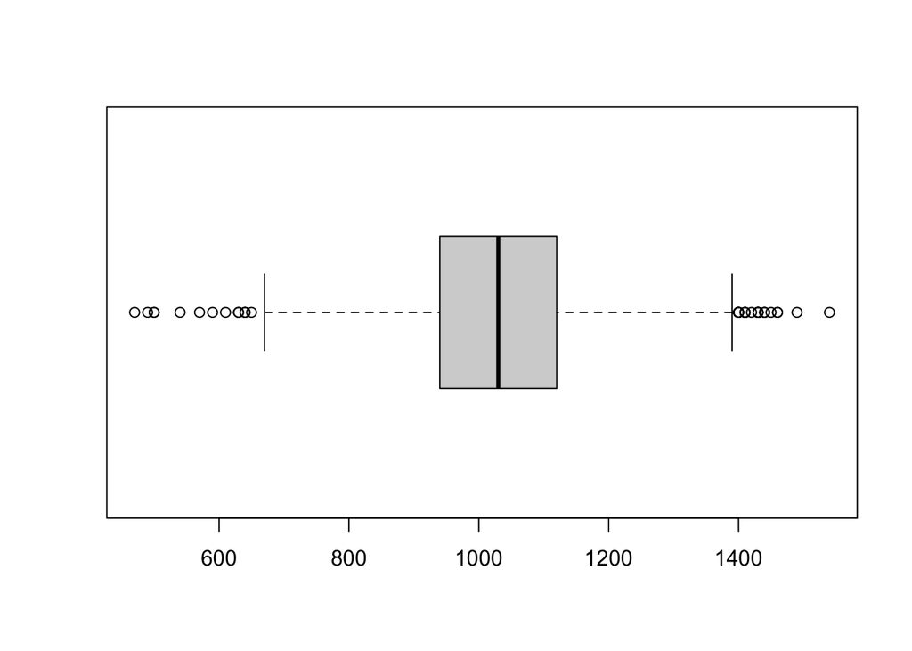

```r
info_sat<-boxplot(gpa$sat, horizontal = TRUE)
```

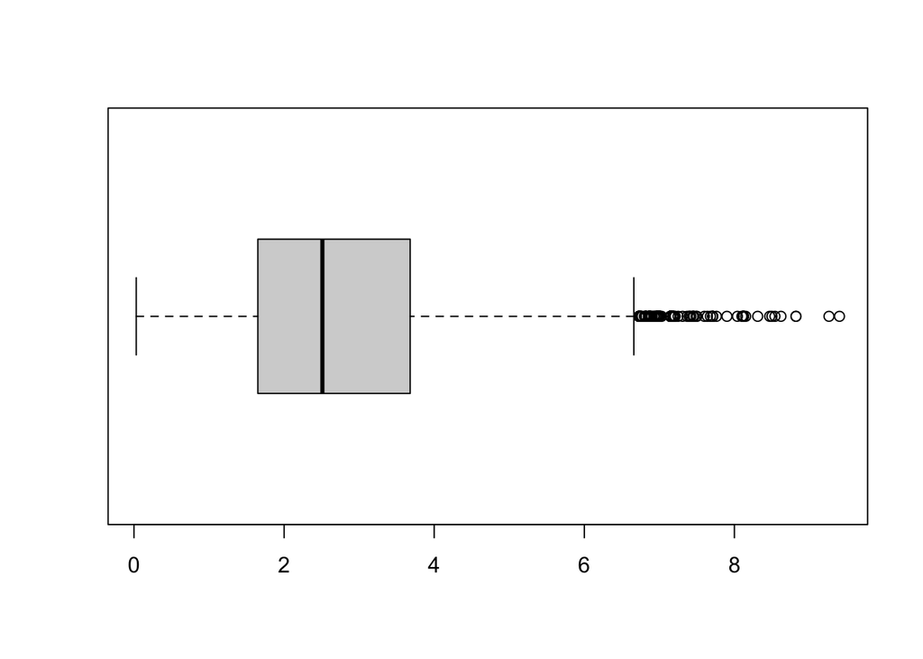

```r
info_hsize<-boxplot(gpa$hsize, horizontal = TRUE)
```

```r
summary(gpa$sat)
```

```
##    Min. 1st Qu.  Median    Mean 3rd Qu.    Max.
##     470     940    1030    1030    1120    1540
```

```r
summary(gpa$hsize)
```

```
##    Min. 1st Qu.  Median    Mean 3rd Qu.    Max.
##    0.03    1.65    2.51    2.80    3.68    9.40
```

Dado que ninguno de ellos es anomalo, **no** sustituiremos ninguno por Na.

Un valor atípico o *outlier* está definido por Q3+1.5xIQR (*right outlier*) y Q1-1.5xIQR (*left outlier*)

```r
sprintf("Left outlier sat: %s", sum(gpa$sat<info_sat$stats[1]))
```

```
## [1] "Left outlier sat: 14"
```

```r
sprintf("Right outlier sat: %s", sum(gpa$sat>info_sat$stats[5]))
```

```
## [1] "Right outlier sat: 25"
```

```r
sprintf("Left outlier hsize: %s", sum(gpa$hsize<info_hsize$stats[1]))
```

```
## [1] "Left outlier hsize: 0"
```

```r
sprintf("Right outlier hsize: %s", sum(gpa$hsize>info_hsize$stats[5]))
```

```
## [1] "Right outlier hsize: 169"
```

# 5 Imputación de valores

Los únicos valores Nulos estan en la columna colgpa. Estos serán los que imputemos

```r
summary(gpa)
```

```
##       sat           tothrs           hsize          hsrank
##  Min.   : 470   Min.   :  6.00   Min.   :0.03   Min.   :  1.00
##  1st Qu.: 940   1st Qu.: 17.00   1st Qu.:1.65   1st Qu.: 11.00
##  Median :1030   Median : 47.00   Median :2.51   Median : 30.00
##  Mean   :1030   Mean   : 52.83   Mean   :2.80   Mean   : 52.83
##  3rd Qu.:1120   3rd Qu.: 80.00   3rd Qu.:3.68   3rd Qu.: 70.00
##  Max.   :1540   Max.   :137.00   Max.   :9.40   Max.   :634.00
##
##      hsperc            colgpa       athlete       female       white
##  Min.   : 0.1667   Min.   :0.000   FALSE:3943   FALSE:2277   FALSE: 308
##  1st Qu.: 6.4328   1st Qu.:2.210   TRUE : 194   TRUE :1860   TRUE :3829
##  Median :14.5833   Median :2.660
##  Mean   :19.2371   Mean   :2.655
##  3rd Qu.:27.7108   3rd Qu.:3.120
##  Max.   :92.0000   Max.   :4.000
##                    NA's   :41
##    black
##  FALSE:3908
##  TRUE : 229
##
##
##
##
##
```

Como mencionado en el ejercicio, usaré la función *kNN* de la libraría *VIM* con un número de vecinos de 11.

La imputación utiliza la distancia de Gower y usando como registro cada genero por separado.

```r
# Get indexes of rows to imput
female_imp<-which(gpa$female == TRUE & is.na(gpa$colgpa))
male_imp<-which(gpa$female == FALSE & is.na(gpa$colgpa))
```

A modo ilustrativo veamos algunas columnas con NA

```r
head(gpa[female_imp,])
```

```
##       sat tothrs hsize hsrank    hsperc colgpa athlete female white black
## 100  1120     49  0.10      1 10.000000     NA   FALSE   TRUE  TRUE FALSE
## 318  1050     12  3.70     30  8.108109     NA   FALSE   TRUE  TRUE FALSE
## 629   860     80  6.55    100 15.267180     NA   FALSE   TRUE  TRUE FALSE
## 1172  990     82  3.62     20  5.524862     NA   FALSE   TRUE  TRUE FALSE
## 1238 1060    120  4.39     32  7.289294     NA   FALSE   TRUE  TRUE FALSE
## 1319 1100     82  5.11     61 11.937380     NA   FALSE   TRUE  TRUE FALSE
```

Imputación para valores NA en mujeres

```r
female_knn<-kNN(gpa[which(gpa$female==TRUE),],variable='colgpa',k=11)
gpa[female_imp,]$colgpa <- female_knn[which(female_knn$colgpa_imp==TRUE),]$colgpa
```

Imputación para valores NA en hombres

```r
male_knn<-kNN(gpa[which(gpa$female==FALSE),],variable='colgpa',k=11)
gpa[male_imp,]$colgpa<-male_knn[which(male_knn$colgpa_imp==TRUE),]$colgpa
```

Comprobamos que no quedan valores NA

```r
sum(is.na(gpa$colgpa))
```

```
## [1] 0
```

Veamos las mismas columnas de antes, ahora imputadas

```r
head(gpa[female_imp,])
```

```
##       sat tothrs hsize hsrank    hsperc colgpa athlete female white black
## 100  1120     49  0.10      1 10.000000   3.26   FALSE   TRUE  TRUE FALSE
## 318  1050     12  3.70     30  8.108109   2.60   FALSE   TRUE  TRUE FALSE
## 629   860     80  6.55    100 15.267180   2.82   FALSE   TRUE  TRUE FALSE
## 1172  990     82  3.62     20  5.524862   2.81   FALSE   TRUE  TRUE FALSE
## 1238 1060    120  4.39     32  7.289294   2.89   FALSE   TRUE  TRUE FALSE
## 1319 1100     82  5.11     61 11.937380   2.94   FALSE   TRUE  TRUE FALSE
```

# 6 Creación de una nueva variable

Una nueva columna con las siguiente condiciones en base a **colgpa**

· A de 3.50 a 4.00

· B de 2.50 a 3.49

· C de 1.50 a 2.49

· D de 0 a 1.49

```r
gpaletter<-gpa$colgpa
gpaletter[gpaletter>=3.5] <- 'A'
gpaletter[gpaletter<3.5 & gpaletter>=2.5] <- 'B'
gpaletter[gpaletter<2.5 & gpaletter>=1.5] <- 'C'
gpaletter[gpaletter<1.5] <- 'D'
```

Visualizamos el resultado

```r
table(gpaletter)
```

```
## gpaletter
##    A    B    C    D
##  458 1995 1540  144
```

Añadimos la columna

```r
gpa$gpaletter<-gpaletter
gpa$gpaletter<-factor(gpa$gpaletter)
```

# 7 Estudio descriptivo

## 7.1 Estudio descriptivo de las variablas cualitativas

**Primer gráfico**

La variable **athlete** en porcentaje de atletas

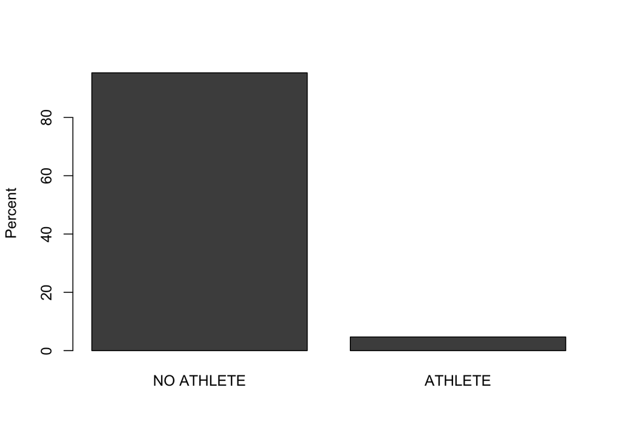

```r
porc_athlete<- t(prop.table(table(gpa$athlete))) * 100
colnames(porc_athlete)<- c("NO ATHLETE", "ATHLETE")
barplot(porc_athlete, ylab = "Percent")
```

**Segundo gráfico**

La variable **athlete** en función del sexo

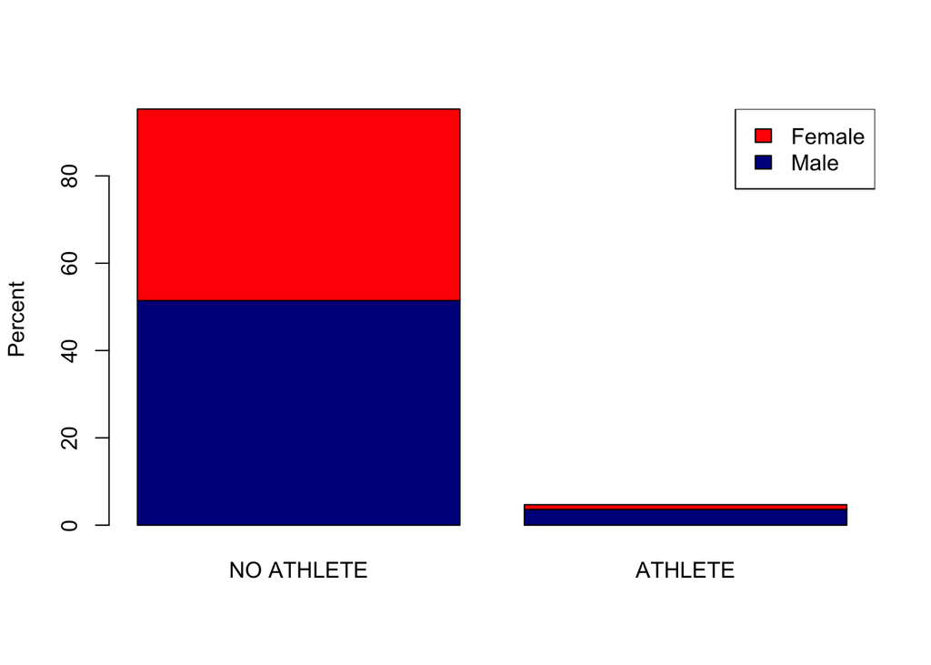

```r
porc_athlete_gender<- t(prop.table(table(gpa$athlete,gpa$female))) * 100
colnames(porc_athlete_gender)<- c("NO ATHLETE", "ATHLETE")
barplot(porc_athlete_gender,ylab="Percent",col=c("darkblue","red"))
legend("topright",legend = c("Female", "Male"),fill = c("red", "darkblue"))
```

## 7.2 Estudio descriptivo de las variables cuantitativas

Estudio descriptivo de las variables **sat**, **tothrs**, **hsize** y **hrank**

*Distribución sat*

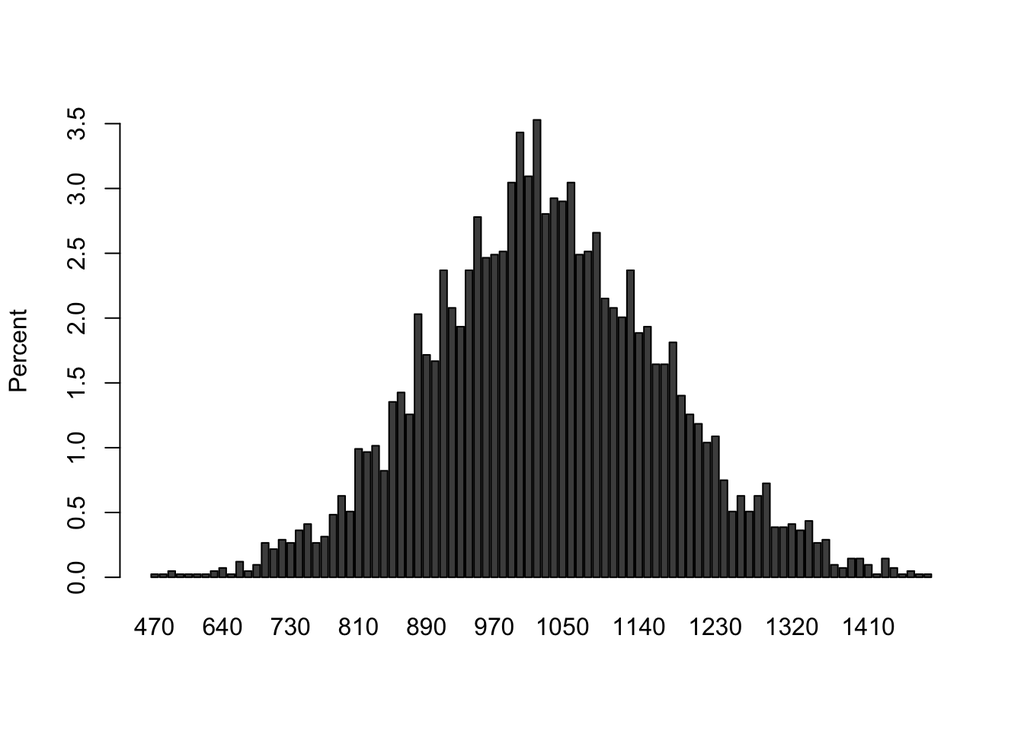

```r
porc_sat<-t(prop.table(table(gpa$sat))) * 100
barplot(porc_sat,ylab="Percent")
```

*Distribución sat en función del sexo*

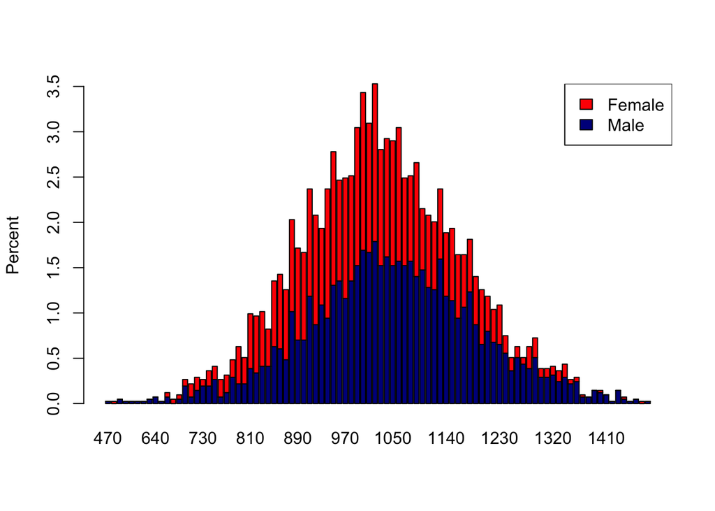

```r
porc_sat_gender<-t(prop.table(table(gpa$sat,gpa$female))) * 100
barplot(porc_sat_gender,ylab="Percent",col=c("darkblue","red"))
legend("topright",legend = c("Female", "Male"),fill = c("red", "darkblue"))
```

*Distribución tothrs*

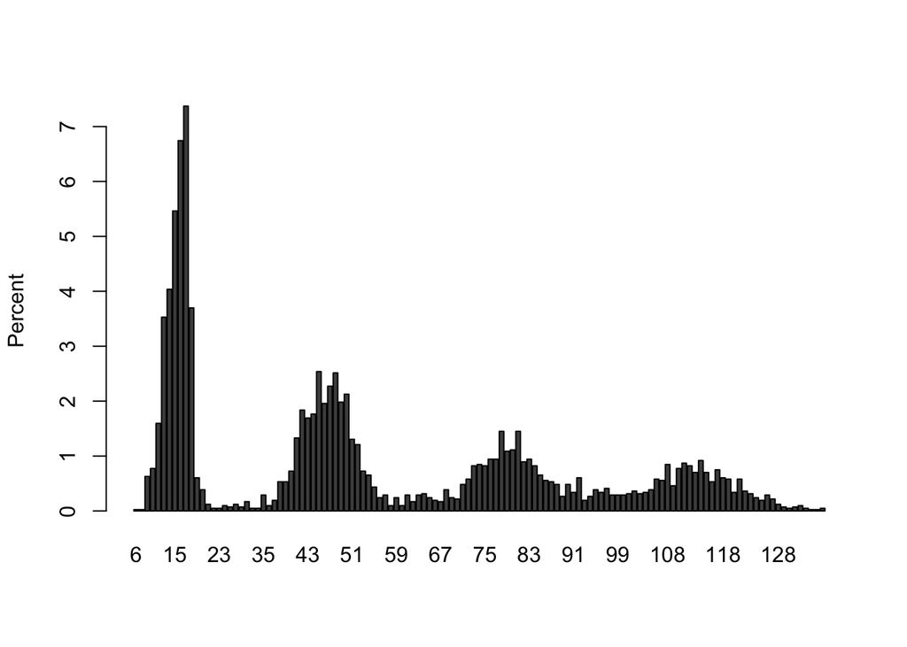

```r
porc_tothrs<-t(prop.table(table(gpa$tothrs))) * 100
barplot(porc_tothrs,ylab="Percent")
```

*Distribución hsize*

En este caso uso la función ceiling sino crearía muchas entradas que no aportan mucha información

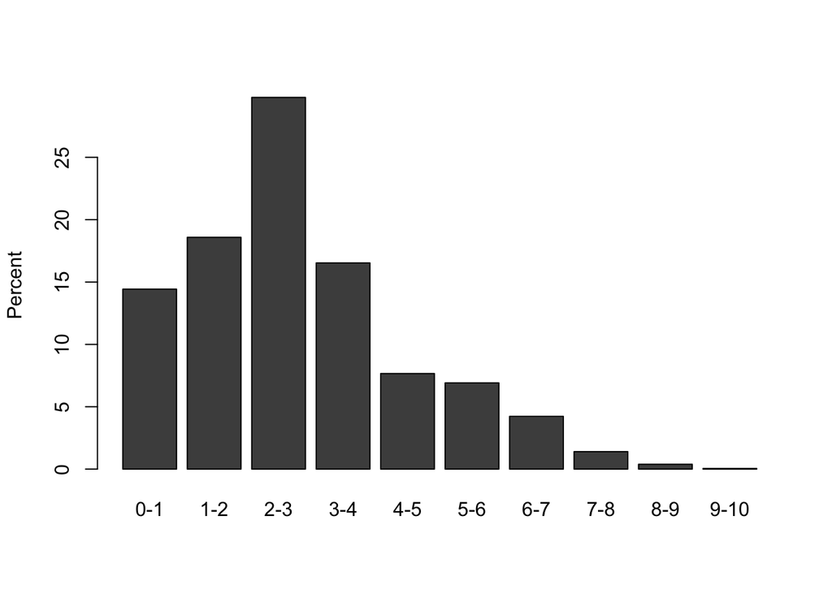

```r
porc_hsize<-t(prop.table(table(ceiling(gpa$hsize)))) * 100
colnames(porc_hsize)<- c("0-1", "1-2","2-3","3-4","4-5","5-6","6-7","7-8","8-9","9-10")
barplot(porc_hsize,ylab="Percent")
```

*Distribución hsrank*

Aquí los porcentajes no son muy indicativos. Por eso he optado por el histograma

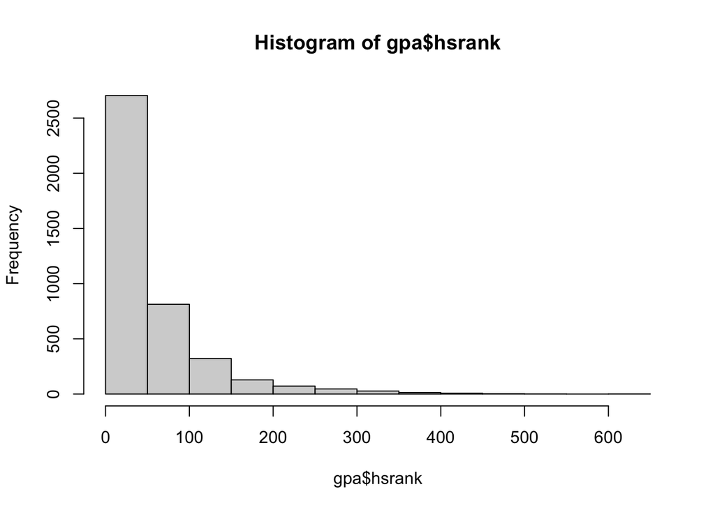

```r
hist(gpa$hsrank)
```

*Tabla con medidas de distribución*

```r
table_sat<-summary(gpa$sat)[c(1,3,4,6)]
table_tothrs<-summary(gpa$tothrs)[c(1,3,4,6)]
table_hsize<-summary(gpa$hsize)[c(1,3,4,6)]
table_hsrank<-summary(gpa$hsrank)[c(1,3,4,6)]
table_cuantitative<-data.frame(MIN=c(table_sat[1],table_tothrs[1],table_hsize[1],table_hsrank[1]),
          MEDIAN=c(table_sat[2],table_tothrs[2],table_hsize[2],table_hsrank[2]),
          MEAN=c(table_sat[3],table_tothrs[3],table_hsize[3],table_hsrank[3]),
          MAX=c(table_sat[4],table_tothrs[4],table_hsize[4],table_hsrank[4]),
          VAR=c(var(gpa$sat),var(gpa$tothrs),var(gpa$hsize),var(gpa$hsrank)),
          SD=c(sd(gpa$sat),sd(gpa$tothrs),sd(gpa$hsize),sd(gpa$hsrank)))
rownames(table_cuantitative) <- c("SAT","TOTHRS","HSIZE","HSRANK")
table_cuantitative
```

```
##           MIN  MEDIAN        MEAN    MAX          VAR         SD
## SAT    470.00 1030.00 1030.331158 1540.0 19432.748142 139.401392
## TOTHRS   6.00   47.00   52.832246  137.0  1248.180266  35.329595
## HSIZE    0.03    2.51    2.799727    9.4     3.015708   1.736579
## HSRANK   1.00   30.00   52.830070  634.0  4183.966039  64.683584
```

# 8 Archivo final

Guardar el data frame en un archivo **gpa_clean.csv**

```r
write.csv(gpa,'gpa_clean.csv')
```

# 9 Informe ejecutivo

## 9.1 Tabla resumen del preprocesamiento

```r
aux<-read.csv('gpa_row.csv')
types_start<-c(sapply(aux[1,],typeof),NA)
names(types_start)[11]<-"gpaletter"
types_end<-sapply(gpa[1,],typeof)
example<-t(gpa[1,])
mod_sat<-sum(is.na(as.numeric(aux$sat)))
mod_tothrs<-sum(endsWith(aux$tothrs,"h"))
mod_hsize<-length(grep(",",aux$hsize))
mod_hsrank<-sum(is.na(aux$hsrank))
mod_hsprec<-sum(round(gpa$hsrank/gpa$hsize,digits=3) != round(aux$hsperc,digits=3))
mod_colgpa<-sum(is.na(aux$colgpa))
mod_athlete<-length(which(aux$white != 'TRUE' & aux$white != 'FALSE'))
mod_female<-sum(is.na(aux$female))
mod_white<-length(which(aux$white != 'TRUE' & aux$white != 'FALSE'))
mod_black<-length(which(aux$black != 'TRUE' & aux$black != 'FALSE'))
mod_gpaletter<-nrows
modified_rows<-c(mod_sat,mod_tothrs,mod_hsize,mod_hsrank,mod_hsprec,mod_colgpa,mod_athlete,mod_female,mod_white,mod_black,mod_gpaletter)
type_of_change<-c("Change type","Remove last character & Change type", "Replace , for . & Change type", "Change type", "Calculate hsrank/hsize", "Impute NA values", "Correct strings & Change type", "Change type", "Correct strings & Change type", "Correct strings & Change type", "Categorize colgpa")
tabla_resumen<-data.frame(types_start,example,types_end, type_of_change, modified_rows)
names(tabla_resumen)[2]<-"Example"
tabla_resumen
```

[output not shown]

De manera más especifica mencionar:

· **tothrs**: Borrar el último carácter que siempre era *h*. *43h* -> *43*

· **hsize**: Cambiar cada valor que tenga una coma `,` por un punto `.`

· **hsperc**: Cuando **hsrank/hsize** no coincide con **hsperc** con una precisión mínima de 3 digitos. Lo calculo de nuevo

· **colgpa**: Imputamos los valores NA con la función kNN de la libreria VIM con k=11

· **athlete**: Los valores se han adaptado para que sean TRUE o FALSE. Sin espacios y en Mayúsculas

· **white**: Los valores se han adaptado para que sean TRUE o FALSE. Sin espacios y en Mayúsculas

· **black**: Los valores se han adaptado para que sean TRUE o FALSE. Sin espacios y en Mayúsculas

· **gpaletter**: Se ha asignado una letra para cada nota. A, de 3.50 a 4.00; B, de 2.50 a 3.49; C, de 1.50 a 2.49; D, de 0 a 1.49.

## 9.2 Resumen estadístico

*sat*

Como hemos observado en el plot de sat (apartado 7.2) vemos que sat tiene una distribución normal.

Cosa que incluso es lógico dado que son las notas de acceso y por parte de las universidades se busca adaptar los estudios para que las

notas vayan en función de una distribución normal

*tothrs*

Aquí cabe destacar que se forman 4 picos de datos entorno las 15,50,80 y 110 horas semestrales.

*hsize*

*hsrank*

Aquí se forma una *long tail* distribución.

*colgpa*

También se asemeja a una distribución normal

*athlete*

Esta variable está descompensada. Encontramos un 95.31% de estudiantes que NO son atletas y solo un 4.69% que si lo son

*female*

Esta variable esta bastante igualada como era de esperar entre el número de hombres (55%) y el número de mujeres (45%)

*white* y *black*

Estas dos variables se podrían unificar en 1. El 93% tienen white==TRUE, el 6% black==TRUE y el resto no está en ninguna de las 2 columnas.

Por tanto se podría poner una unica columna llamada race con los valores white,black y other o 0,1 y 2.

*gpaletter*

Como cabe de esperar la distribución se asemeja a la de **colgpa**